# 291 HW2

Vidushi Kataria

2024-02-07

```r
Worldlife100 <- read.csv("Worldlife.csv")
install.packages("ggplot2")
library(ggplot2)
library(dplyr)
```

## PART 1: Regression of life expectancy in 2023 on life expectancy in 1923

# Question 1

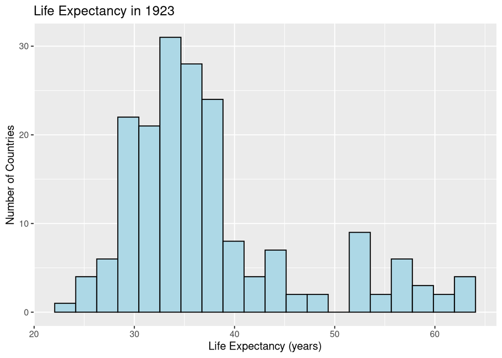

```r
ggplot(Worldlife100, aes(x = life1923)) +
  geom_histogram(bins=20, color="black", fill="lightblue") +
  labs(title="Life Expectancy in 1923",
       x="Life Expectancy (years)",
       y="Number of Countries")
```

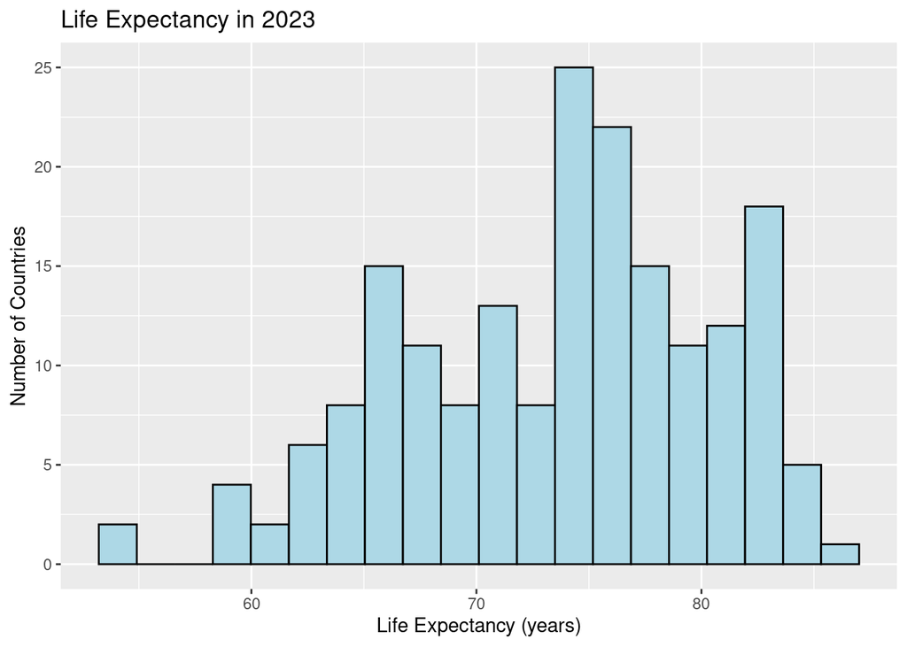

```r
ggplot(Worldlife100, aes(x = life2023)) +
   geom_histogram(bins=20, color="black", fill="lightblue") +
   labs(title = "Life Expectancy in 2023",
        x = "Life Expectancy (years)",
        y = "Number of Countries")
```

# 1923 plot - The distribution has a single peak that is right-skewed. # There are two clear peaks in the histogram, indicating two predominant modes/clusters in the data. Most of the values on the right side have a higher trajectory, meaning that this histogram is left-skewed.

## Q2

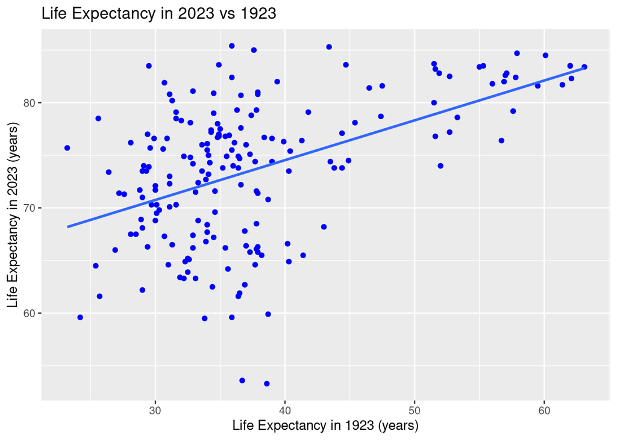

```r
ggplot(Worldlife100, aes(x = life1923, y = life2023)) +
  geom_point(color="blue") +
  geom_smooth(method="lm", se=FALSE) +
  labs(title="Life Expectancy in 2023 vs 1923",
       x="Life Expectancy in 1923 (years)",
       y="Life Expectancy in 2023 (years)")
```

# There is a positive linear relationship between life expectancy in 1923 and life expectancy in 2023. Countries with higher life expectancy in 1923 also tended to have higher life expectancy in 2023.

## Q3

```r
cor(Worldlife100$life1923, Worldlife100$life2023)
```

```
## [1] 0.4929469
```

# Positive correlation: 0.49

# The coefficient of determination R2:0.49^2 = 0.2401

Approximately 24% of the variance in Y can be explained by the linear relationship between X and Y.

## Q4

```r
fit <- lm(life2023 ~ life1923, data=Worldlife100)
summary(fit)
```

```
##
## Call:
## lm(formula = life2023 ~ life1923, data = Worldlife100)
##
## Residuals:
##     Min      1Q  Median      3Q     Max
## -20.710  -3.687   1.020   3.961  12.933
##
## Coefficients:
##             Estimate Std. Error t value Pr(>|t|)
## (Intercept) 59.40509    1.90355  31.208  < 2e-16 ***
## life1923     0.37837    0.04923   7.685 8.83e-13 ***
## ---
## Signif. codes:  0 '***' 0.001 '**' 0.01 '*' 0.05 '.' 0.1 ' ' 1
##
## Residual standard error: 5.949 on 184 degrees of freedom
## Multiple R-squared:  0.243,  Adjusted R-squared:  0.2389
## F-statistic: 59.06 on 1 and 184 DF,  p-value: 8.834e-13
```

# The model is highly significant with p-value < 0.001.

## Q5

```r
coef(fit) [2]
```

```
##  life1923
## 0.3783683
```

# If life expectancy in 1923 increases by 1 year, the expected increase in life expectancy in 2023 is 0.38 years.

## Q6

```r
new.worldlife <- data.frame(life1923 = 34.3)
pred <- 34.3*coef(fit) [2] + coef(fit) [1]
print(pred)
```

```
## life1923
## 72.38312
```